# Distribution_of_linear_regression_coeffients

Xuening

4/15/2020

## An example of falling object

Suppose an object falls from $56.67m$ with initial velocity $0m/s$. Suppose we measure its location at different moments to try to estimate gravitational constant. Finally we suppose measurement error is normally distributed with standard deviation 1.

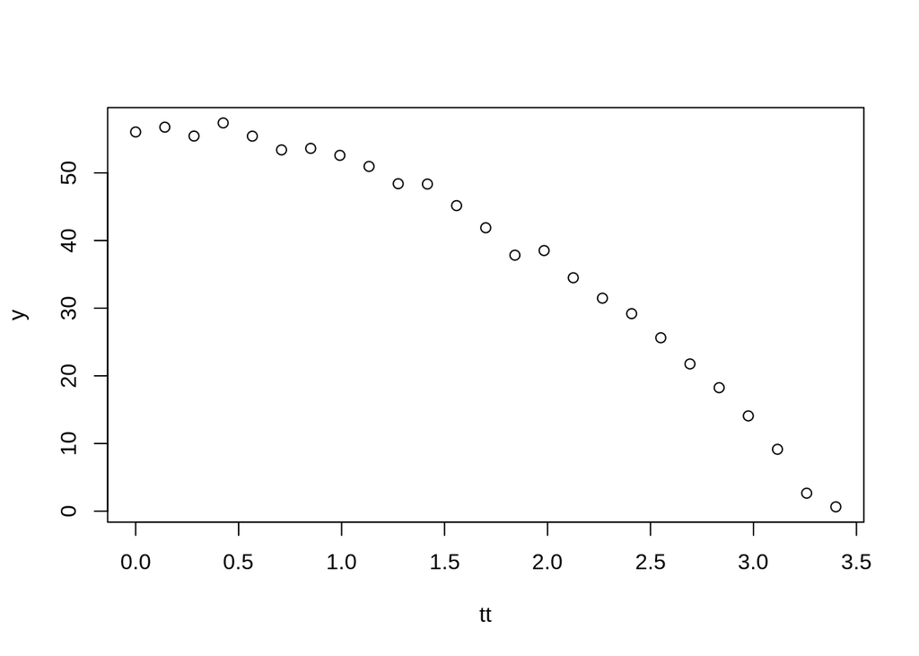

```r
h0 <- 56.67
g <- 9.8
n <- 25
tt <- seq(0,3.4,len=n)
set.seed(1)
y <- h0-0.5*g*tt^2+rnorm(n,mean=0,sd=1)
plot(tt,y)
```

Then let’s fit the observation `y` with a linear model to figure out $g$. To be more concrete:

$$y=
\left[
\begin{matrix}
y_1\\
y_2\\
\vdots\\
y_n\\
\end{matrix}
\right]$$

$$X=
\left[
\begin{matrix}
1 & t_1 & t_1^2\\
1 & t_2 & t_2^2\\
\vdots &\vdots &\vdots\\
1 & t_n & t_n^2\\
\end{matrix}
\right]$$

$$\beta=
\left[
\begin{matrix}
\beta_1\\
\beta_2\\
\beta_3\\
\end{matrix}
\right]=
\left[
\begin{matrix}
h_0\\
v_0\\
-\frac{1}{2}g\\
\end{matrix}
\right]$$
$$\epsilon=
\left[
\begin{matrix}
\epsilon_1\\
\epsilon_2\\
\vdots\\
\epsilon_n\\
\end{matrix}
\right]$$

Our model is:
$$y=X\beta+\epsilon$$
And solution is:
$$\beta=(X^T X)^{-1}X^T Y$$

```r
X <- model.matrix(~tt+I(tt^2))
head(X)
```

```
##   (Intercept)        tt    I(tt^2)
## 1           1 0.0000000 0.00000000
## 2           1 0.1416667 0.02006944
## 3           1 0.2833333 0.08027778
## 4           1 0.4250000 0.18062500
## 5           1 0.5666667 0.32111111
## 6           1 0.7083333 0.50173611
```

```r
beta <- solve(crossprod(X)) %*% t(X) %*% y
beta
```

```
##                   [,1]
## (Intercept) 56.5317368
## tt           0.5013565
## I(tt^2)     -5.0386455
```

Here true value of `beta[3]` is the $-\frac{1}{2}g$. Since it’s a linear combination of $y$, it will change as $y$ changes due to measurement error. What is the distribution of `beta[3]`, if we measure $y$ for 10000 times? Let’s first build a function to find beta automatically. Then repeat for 10000 times

```r
find_beta3 <- function(){
        y <- h0-0.5*g*tt^2+rnorm(n,mean=0,sd=1)
        beta <- solve(crossprod(X)) %*% t(X) %*% y
        return(beta[3])
}
set.seed(1)
beta3 <- replicate(10000,find_beta3())
head(beta3)
```

```
## [1] -5.038646 -4.894362 -5.143756 -5.220960 -5.063322 -4.777521
```

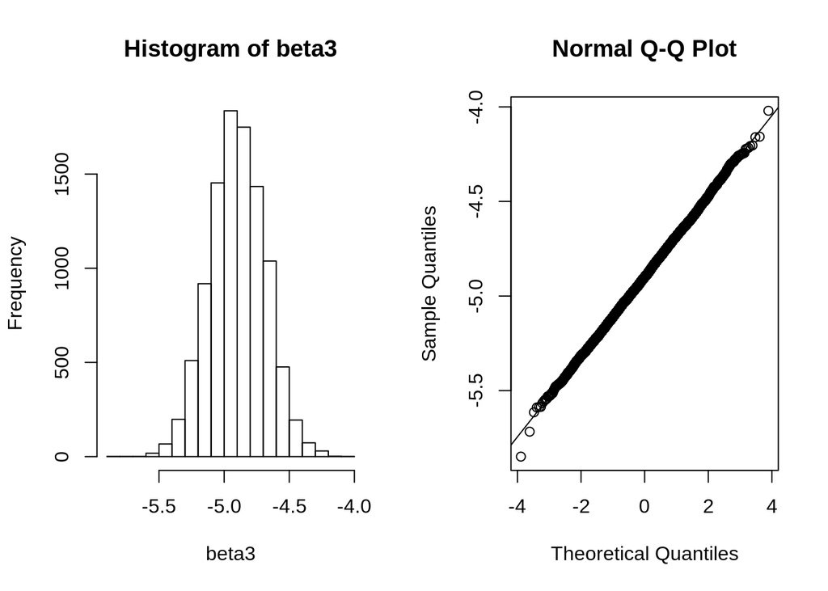

```r
par(mfrow=c(1,2))
hist(beta3,breaks=20)
qqnorm(beta3)
qqline(beta3)
```

```r
mean(beta3)
```

```
## [1] -4.897816
```

```r
sd(beta3)
```

```
## [1] 0.2129976
```

Look $\beta_3$ is normal distributed around its true value: -4.9 with standard deviation around 0.2. This is not an accident because $\beta_3$ is a linear combination of $y$, and $y$ is normally distributed.

## Covariance matrix of $Y$

In the previous discussions, $y$ is one observation containing 25 numbers written in one column. If we pile up our 5 observations column by column, we’ll get a matrix $Y$.

```r
Y <- replicate(5,h0-0.5*g*tt^2+rnorm(n,mean=0,sd=1))
head(Y)
```

```
##          [,1]     [,2]     [,3]     [,4]     [,5]
## [1,] 56.91146 56.42936 55.04757 57.96586 57.46148
## [2,] 56.16459 55.70238 56.86074 57.39423 56.94233
## [3,] 56.28976 56.23081 56.35078 56.51833 56.53624
## [4,] 56.54062 53.49724 55.18379 54.51491 55.77716
## [5,] 54.63687 55.50897 54.85186 55.08951 53.70756
## [6,] 53.71630 52.64929 52.45961 54.32246 53.39795
```

```r
cov(Y)
```

```
##          [,1]     [,2]     [,3]     [,4]     [,5]
## [1,] 327.0574 315.2870 322.7458 327.6761 322.0051
## [2,] 315.2870 307.1293 312.7682 316.8586 311.1927
## [3,] 322.7458 312.7682 320.5145 323.9950 318.7407
## [4,] 327.6761 316.8586 323.9950 329.8232 323.1511
## [5,] 322.0051 311.1927 318.7407 323.1511 318.3972
```

Is this the covariance matrix of $Y$ mathematically? No, because mathematically $X$ is considered fixed. That is to say, Denote the $i$-th observation $Y_i$, then $var(Y_i)=var(X\beta)+var(\epsilon_i)$, and $var(X\beta)=0$ (this is where math and code differ) so $var(Y_i)=var(\epsilon_i)=\sigma^2$. Let’s subtract the variance that $X$ can explain and try again.

```r
beta <- matrix(c(56.67,0,-4.9))
cov(Y-as.numeric(X%*%beta))
```

```
##            [,1]        [,2]        [,3]       [,4]        [,5]
## [1,]  0.8681823 -0.51506100 -0.33486830  0.2864384  0.16664286
## [2,] -0.5150610  1.71431448  0.07454279 -0.1439646 -0.25864105
## [3,] -0.3348683  0.07454279  0.54222827 -0.2861957  0.01072708
## [4,]  0.2864384 -0.14396459 -0.28619567  1.2330946  0.11212935
## [5,]  0.1666429 -0.25864105  0.01072708  0.1121294  0.90939154
```

Theoretically,
$$Cov(Y_i,Y_i)=var(Y_i)=\sigma^2$$
Since obeservations are independent of each other, we have
$$Cov(Y_i,Y_j)=0, i\neq j$$
Therefore,the variance-covariance matrix of $Y$ is:
$$var(Y)=\sigma^2 I$$
Here $\sigma^2$ is the variance of $\epsilon$ (measurement error), but still unknown. We need to estimate it.

## Estimate $\sigma^2$

Define residual $r=y-X\hat\beta$, then $r$ is an estimation of $\epsilon$.
$$\hat\sigma^2=\frac{1}{n-p}r^T r=\frac{1}{n-p}\sum_{i=1}^n r_i^2$$
Here $n$ is sample size and $p$ is the number of parameters, or the number of columns in $X$. From the simulation process we know the true value $\sigma^2=1$. Let’s estimate $\sigma^2$ using residuals.

```r
beta <- solve(crossprod(X)) %*% t(X) %*% y
r <-y-X%*%beta
sigma_hat2 <- sum(r^2)/(25-3)
sigma_hat2
```

```
## [1] 0.9647636
```

## Estimate standard error of $\beta$

$\beta$ is a linear combination of y: $\beta=Ay$ with $A=(X^TX)^{-1}X^T$. Since
$$var(Ay)=Avar(y)A^T$$
We have
$$var(\hat\beta)=\sigma^2(X^T X)^{-1}$$

This result can also be interpreted intuitively. The large the variance in independent variable, the smaller the variance (uncertainty) of least square estimation. Intuitively this is because large variance in independent variable contain more information.

Let’s compute the variance of $\beta$,

```r
var_beta <- sigma_hat2*solve(crossprod(X))
var_beta
```

```
##             (Intercept)         tt     I(tt^2)
## (Intercept)  0.29718018 -0.3422510  0.08217311
## tt          -0.34225099  0.5514530 -0.15131621
## I(tt^2)      0.08217311 -0.1513162  0.04450477
```

then the standard deviation of $\beta_3$:

```r
sqrt(var_beta[3,3])
```

```
## [1] 0.2109615
```

Let’s compare with the result of `lm()`:

```r
summary(lm(y~X))
```

```
##
## Call:
## lm(formula = y ~ X)
##
## Residuals:
##     Min      1Q  Median      3Q     Max
## -2.5295 -0.4882  0.2537  0.6560  1.5455
##
## Coefficients: (1 not defined because of singularities)
##              Estimate Std. Error t value Pr(>|t|)
## (Intercept)   56.5317     0.5451 103.701   <2e-16 ***
## X(Intercept)       NA         NA      NA       NA
## Xtt            0.5014     0.7426   0.675    0.507
## XI(tt^2)      -5.0386     0.2110 -23.884   <2e-16 ***
## ---
## Signif. codes:  0 '***' 0.001 '**' 0.01 '*' 0.05 '.' 0.1 ' ' 1
##
## Residual standard error: 0.9822 on 22 degrees of freedom
## Multiple R-squared:  0.9973, Adjusted R-squared:  0.997
## F-statistic:  4025 on 2 and 22 DF,  p-value: < 2.2e-16
```

0.2109615. The same!

Notice: `Std. Error` is just the standard deviation of each coefficient.

Notice, the `Residual standard error` is $\hat\sigma$, the estimation of standard deviation of $\epsilon$. We can try.

```r
sqrt(sigma_hat2)
```

```
## [1] 0.9822238
```

0.9822! The same!

The last thing to notice: $t=\frac{\hat\beta}{sd(\hat\beta)}$ observes t distribution, with degree of freedom $n-p$

```r
tval <- summary(lm(y~X))$coef[2,1]/summary(lm(y~X))$coef[2,2]
tval
```

```
## [1] 0.6751378
```

```r
pval <- 2*pt(-abs(tval),df=25-3)
pval
```

```
## [1] 0.5066226
```

As `Pr(>|t|)` tells us, the intercept and the coefficients for `tt^2` is significantly different from $0$, but the coefficient for `tt` is not significantly different from $0$.